# Lab 10 - Regression Final — ANSWER KEY

ANTH 3900 / 5203

```r
library(MASS)
library(AER)
library(DAAG)
library(margins)
library(tidyverse)
```

## Dataset 1: Pima Indians Diabetes

**Correct model: Binary Logistic Regression** (`family = binomial(link = "logit")`)

### Justification (model answer)

> The outcome variable `type` is binary — it takes values `Yes` or `No` indicating a positive diabetes diagnosis. Because the outcome is categorical with two levels, ordinary linear regression is inappropriate (it can produce predicted probabilities outside [0, 1] and violates normality assumptions). Binary logistic regression models the log odds of the outcome as a linear function of the predictors using a logit link function, making it the correct choice. There is no strong theoretical reason to prefer a probit link here, so logistic regression is the default.

```r
data("Pima.tr", package = "MASS")

# Examine the outcome
str(Pima.tr$type)
```

```
 Factor w/ 2 levels "No","Yes": 1 2 1 1 1 2 1 1 1 2 ...
```

```r
table(Pima.tr$type)
```

```
 No Yes
132  68
```

```r
# Ensure type is a factor coded 0/1
Pima.tr$type_bin <- ifelse(Pima.tr$type == "Yes", 1, 0)

fit1 <- glm(type_bin ~ glu + bmi + bp + age,
            data = Pima.tr,
            family = binomial(link = "logit"))

summary(fit1)
```

```
Call:
glm(formula = type_bin ~ glu + bmi + bp + age, family = binomial(link = "logit"),
    data = Pima.tr)

Coefficients:
             Estimate Std. Error z value Pr(>|z|)
(Intercept) -9.144169   1.647351  -5.551 2.84e-08 ***
glu          0.031224   0.006560   4.760 1.94e-06 ***
bmi          0.093564   0.032645   2.866  0.00416 **
bp          -0.006076   0.017345  -0.350  0.72612
age          0.054793   0.018166   3.016  0.00256 **
---
Signif. codes:  0 '***' 0.001 '**' 0.01 '*' 0.05 '.' 0.1 ' ' 1

(Dispersion parameter for binomial family taken to be 1)

    Null deviance: 256.41  on 199  degrees of freedom
Residual deviance: 188.27  on 195  degrees of freedom
AIC: 198.27

Number of Fisher Scoring iterations: 5
```

```r
# Odds ratios with 95% confidence intervals
exp(cbind(OR = coef(fit1), confint(fit1)))
```

```
                     OR        2.5 %      97.5 %
(Intercept) 0.000106841 3.432709e-06 0.002256232
glu         1.031716368 1.019111e+00 1.045813037
bmi         1.098080559 1.031750e+00 1.173441924
bp          0.993942705 9.603156e-01 1.028463777
age         1.056321870 1.020111e+00 1.095860033
```

## Dataset 2: Extramarital Affairs

**Correct model: Binary Logistic Regression or Probit Regression** (both acceptable; task requires fitting and comparing both)

### Justification (model answer)

> After recoding `affairs > 0` as a binary indicator, the outcome `had_affair` takes values 0 (no affair) or 1 (at least one affair). Both logistic and probit regression are appropriate for binary outcomes; they differ in the assumed distribution of the underlying latent distribution. Logistic regression assumes the data follows a logistic distribution, while probit assumes it follows a standard normal distribution. In practice, the two models will yield similar results.

```r
data("Affairs", package = "AER")

Affairs$had_affair <- as.integer(Affairs$affairs > 0)
table(Affairs$had_affair)
```

```
  0   1
451 150
```

```r
fit2_logit <- glm(had_affair ~ gender + age + yearsmarried + children +
                    religiousness + education + rating,
                  data = Affairs,
                  family = binomial(link = "logit"))

fit2_probit <- glm(had_affair ~ gender + age + yearsmarried + children +
                     religiousness + education + rating,
                   data = Affairs,
                   family = binomial(link = "probit"))

AIC(fit2_logit, fit2_probit)
```

```
            df      AIC
fit2_logit   8 625.6964
fit2_probit  8 626.5050
```

**Result:** AIC values are very close (within ~1–2 units). Neither model is meaningfully better — this is expected and is itself an instructive finding.

```r
mfx <- summary(margins(fit2_probit))
mfx
```

```
        factor     AME     SE       z      p   lower   upper
           age -0.0070 0.0030 -2.3440 0.0191 -0.0128 -0.0011
   childrenyes  0.0582 0.0445  1.3081 0.1908 -0.0290  0.1454
     education  0.0044 0.0076  0.5851 0.5585 -0.0104  0.0193
    gendermale  0.0542 0.0375  1.4479 0.1476 -0.0192  0.1277
        rating -0.0781 0.0144 -5.4277 0.0000 -0.1063 -0.0499
 religiousness -0.0533 0.0145 -3.6808 0.0002 -0.0817 -0.0249
  yearsmarried  0.0156 0.0053  2.9561 0.0031  0.0053  0.0260
```

**Key marginal effects to highlight:**

- `rating` (marriage happiness): Strongly negative AME — higher marital satisfaction is associated with a meaningfully lower probability of having an affair.
- `religiousness`: Negative AME — more religious individuals have a lower probability of reporting an affair.

**Grading note:** Students must use `pnorm()` or `margins()` — raw probit coefficients cannot be directly interpreted as probability changes. Deduct points if a student interprets raw coefficients as probability effects.

## Dataset 3: Warp Breaks

**Correct model: Poisson Regression** (`family = poisson`)

*(Students who detect overdispersion and argue for negative binomial receive full credit with appropriate justification)*

### Justification (model answer)

> The outcome `breaks` is a non-negative integer count — the number of times yarn breaks during weaving. OLS is inappropriate because (1) the outcome is bounded at zero and right-skewed, (2) OLS can predict negative counts, and (3) OLS assumes constant variance, which count data typically violates. Poisson regression is designed for count outcomes; it models the log of the expected count as a linear function of predictors, assumes variance equals the mean, and ensures non-negative predictions.

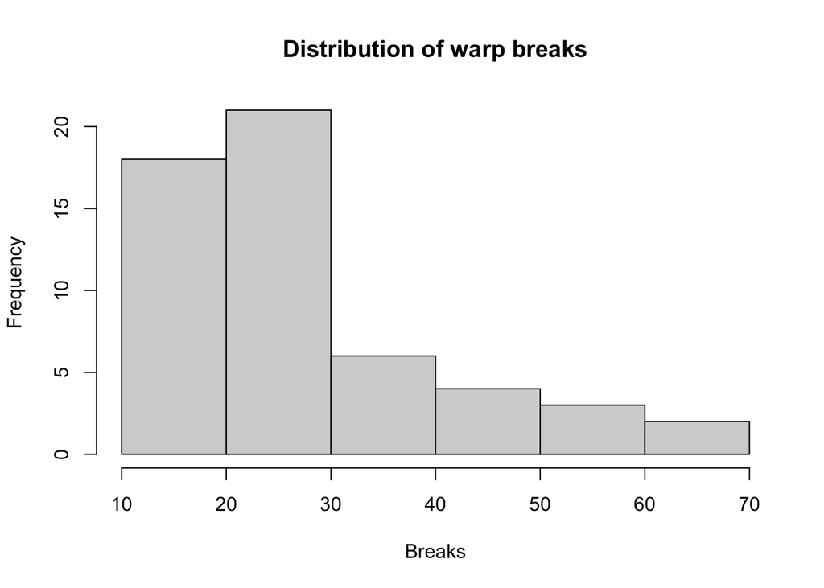

```r
data("warpbreaks")

# Examine outcome
hist(warpbreaks$breaks, main = "Distribution of warp breaks", xlab = "Breaks")
```

```r
mean(warpbreaks$breaks); var(warpbreaks$breaks)
```

```
[1] 28.14815
```

```
[1] 174.2041
```

```r
fit3 <- glm(breaks ~ wool * tension,
            data = warpbreaks,
            family = poisson)

summary(fit3)
```

```
Call:
glm(formula = breaks ~ wool * tension, family = poisson, data = warpbreaks)

Coefficients:
               Estimate Std. Error z value Pr(>|z|)
(Intercept)     3.79674    0.04994  76.030  < 2e-16 ***
woolB          -0.45663    0.08019  -5.694 1.24e-08 ***
tensionM       -0.61868    0.08440  -7.330 2.30e-13 ***
tensionH       -0.59580    0.08378  -7.112 1.15e-12 ***
woolB:tensionM  0.63818    0.12215   5.224 1.75e-07 ***
woolB:tensionH  0.18836    0.12990   1.450    0.147
---
Signif. codes:  0 '***' 0.001 '**' 0.01 '*' 0.05 '.' 0.1 ' ' 1

(Dispersion parameter for poisson family taken to be 1)

    Null deviance: 297.37  on 53  degrees of freedom
Residual deviance: 182.31  on 48  degrees of freedom
AIC: 468.97

Number of Fisher Scoring iterations: 4
```

```r
round(exp(coef(fit3)), 3)
```

```
   (Intercept)          woolB       tensionM       tensionH woolB:tensionM
        44.556          0.633          0.539          0.551          1.893
woolB:tensionH
         1.207
```

**Combination with the most breaks:** Wool A at Low tension (the reference group), with ~44.6 expected breaks.

## Dataset 4: Physician Office Visits

**Correct model: Negative Binomial Regression** (`MASS::glm.nb()`)

### Justification (model answer)

> The outcome `visits` is a count variable recording the number of physician visits in a year. A first instinct is to use Poisson regression, which requires the mean and variance of the outcome to be approximately equal (equidispersion). However, checking the dispersion ratio after fitting a Poisson model reveals severe overdispersion — the variance far exceeds the mean. This is common in healthcare utilization data, where a small number of patients drive a very large number of visits. The negative binomial model relaxes the equidispersion assumption by including an additional dispersion parameter, making it a much better fit for this outcome.

```r
data("NMES1988", package = "AER")

# Examine outcome
summary(NMES1988$visits)
```

```
   Min. 1st Qu.  Median    Mean 3rd Qu.    Max.
  0.000   1.000   4.000   5.774   8.000  89.000
```

```r
var(NMES1988$visits) / mean(NMES1988$visits)  # raw variance-to-mean ratio
```

```
[1] 7.912013
```

```r
fit4_poisson <- glm(visits ~ hospital + health + chronic + gender + school + insurance,
                    data = NMES1988,
                    family = poisson)

# Dispersion check
fit4_poisson$deviance / fit4_poisson$df.residual
```

```
[1] 5.267805
```

```r
fit4_nb <- glm.nb(visits ~ hospital + health + chronic + gender + school + insurance,
                  data = NMES1988)

summary(fit4_nb)
```

```
Call:
glm.nb(formula = visits ~ hospital + health + chronic + gender +
    school + insurance, data = NMES1988, init.theta = 1.206603534,
    link = log)

Coefficients:
                 Estimate Std. Error z value Pr(>|z|)
(Intercept)      0.929257   0.054591  17.022  < 2e-16 ***
hospital         0.217772   0.020176  10.793  < 2e-16 ***
healthpoor       0.305013   0.048511   6.288 3.23e-10 ***
healthexcellent -0.341807   0.060924  -5.610 2.02e-08 ***
chronic          0.174916   0.012092  14.466  < 2e-16 ***
gendermale      -0.126488   0.031216  -4.052 5.08e-05 ***
school           0.026815   0.004394   6.103 1.04e-09 ***
insuranceyes     0.224402   0.039464   5.686 1.30e-08 ***
---
Signif. codes:  0 '***' 0.001 '**' 0.01 '*' 0.05 '.' 0.1 ' ' 1

(Dispersion parameter for Negative Binomial(1.2066) family taken to be 1)

    Null deviance: 5743.7  on 4405  degrees of freedom
Residual deviance: 5044.5  on 4398  degrees of freedom
AIC: 24359

Number of Fisher Scoring iterations: 1

              Theta:  1.2066
          Std. Err.:  0.0336

 2 x log-likelihood:  -24341.1070
```

```r
AIC(fit4_poisson, fit4_nb)
```

```
             df      AIC
fit4_poisson  8 35959.23
fit4_nb       9 24359.11
```

**Expected result:** Negative binomial AIC is dramatically lower than Poisson AIC — confirming the better fit.

```r
round(exp(coef(fit4_nb)), 3)
```

```
    (Intercept)        hospital      healthpoor healthexcellent         chronic
          2.533           1.243           1.357           0.710           1.191
     gendermale          school    insuranceyes
          0.881           1.027           1.252
```

**IRR for `chronic`:**

> Each additional chronic condition is associated with approximately a 17–19% increase in the expected number of physician visits, holding all other variables constant (IRR ≈ 1.17–1.19, highly significant).

## Dataset 5: Space Shuttle O-Ring Failures

**Correct model: Logistic Binomial Regression** (`family = binomial` with `cbind()` outcome)

### Justification (model answer)

> Unlike Datasets 1 and 2 where each observation was a single binary event (one person, one outcome), each observation here represents a group of 6 O-rings per launch, and the outcome is the *count* of O-ring incidents (`Total`) out of that total. This is a grouped binary (binomial) structure — we are modeling a proportion (incidents out of 6) rather than a single 0/1 outcome. Logistic binomial regression handles this by specifying the outcome as a two-column matrix: successes and failures. The model estimates the probability that any individual O-ring has an incident, given the launch temperature.

```r
data("orings", package = "DAAG")

head(orings)
```

```
  Temperature Erosion Blowby Total
1          53       3      2     5
2          57       1      0     1
3          58       1      0     1
4          63       1      0     1
5          66       0      0     0
6          67       0      0     0
```

```r
str(orings)
```

```
'data.frame':   23 obs. of  4 variables:
 $ Temperature: num  53 57 58 63 66 67 67 67 68 69 ...
 $ Erosion    : num  3 1 1 1 0 0 0 0 0 0 ...
 $ Blowby     : num  2 0 0 0 0 0 0 0 0 0 ...
 $ Total      : num  5 1 1 1 0 0 0 0 0 0 ...
```

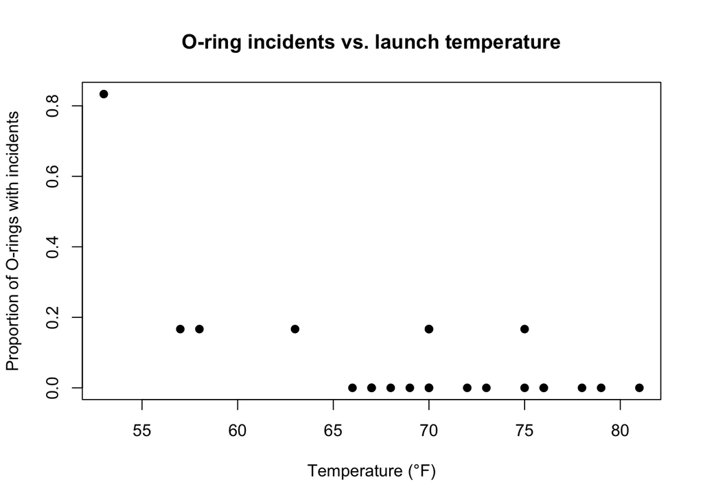

```r
# The dataset has: Temperature, Erosion, Blowby, Total
# Total = Erosion + Blowby (combined incident count out of 6 O-rings)
plot(orings$Temperature, orings$Total / 6,
     xlab = "Temperature (°F)", ylab = "Proportion of O-rings with incidents",
     main = "O-ring incidents vs. launch temperature",
     pch = 19)
```

```r
# Outcome: Total incidents out of 6 O-rings
fit5 <- glm(cbind(Total, 6 - Total) ~ Temperature,
            data = orings,
            family = binomial(link = "logit"))

summary(fit5)
```

```
Call:
glm(formula = cbind(Total, 6 - Total) ~ Temperature, family = binomial(link = "logit"),
    data = orings)

Coefficients:
            Estimate Std. Error z value Pr(>|z|)
(Intercept) 11.66299    3.29626   3.538 0.000403 ***
Temperature -0.21623    0.05318  -4.066 4.78e-05 ***
---
Signif. codes:  0 '***' 0.001 '**' 0.01 '*' 0.05 '.' 0.1 ' ' 1

(Dispersion parameter for binomial family taken to be 1)

    Null deviance: 38.898  on 22  degrees of freedom
Residual deviance: 16.912  on 21  degrees of freedom
AIC: 33.675

Number of Fisher Scoring iterations: 6
```

```r
# Odds ratios
exp(coef(fit5))
```

```
 (Intercept)  Temperature
1.161909e+05 8.055471e-01
```

**Key finding:** Temperature is a significant negative predictor (lower temperature → higher probability of O-ring incidents).

```r
launch_day <- data.frame(Temperature = 31)

pred_prob <- predict(fit5, newdata = launch_day, type = "response")

cat("Predicted probability of incident per O-ring at 31°F:", round(pred_prob, 4), "\n")
```

```
Predicted probability of incident per O-ring at 31°F: 0.993
```

```r
cat("Predicted probability of at least one incident (of 6):", round(1 - (1 - pred_prob)^6, 4), "\n")
```

```
Predicted probability of at least one incident (of 6): 1
```

**Expected result:** Probability per O-ring ≈ 0.80–0.99 at 31°F (well outside the observed data range — students should note this is an extrapolation). Probability of at least one incident ≈ ~1.00.

**Sample written summary:**

> The statistical model shows a clear and significant relationship between launch temperature and the probability of O-ring incidents — lower temperatures substantially increase the risk of failure. When we extrapolate the model to 31°F, the predicted probability of an incident on any individual O-ring is extremely high, meaning the probability that at least one of the six O-rings would fail was effectively 100%. This analysis strongly suggests the launch should not have proceeded. It is important to note that 31°F was well below any temperature ever tested, meaning this prediction is an extrapolation; nevertheless, the trend in the data pointed unambiguously toward catastrophic risk at that temperature.